# Econometría II: Análisis de regresión con datos de series de tiempo

Universidad Centroamericana - Economía Aplicada 2022s2

Alvaro López-Espinoza

# S1: Introducción a las series de tiempo

## 1.1. Datos de la sesión

**Fecha de la sesión:** 2022-08-29

**Lecturas obligatorias:**

- Wooldridge - Cap. 10.1-10.2
- Bee Dagum & Bianconcini - Cap. 2.1.

## 1.2. Naturaleza de las series de tiempo

Existen 4 estructuras básicas de datos:

**Revisar:** Wooldridge - Cap. 1.3

- Datos de corte tranversal: Muestra de unidades tomadas en algún punto dado en el tiempo.

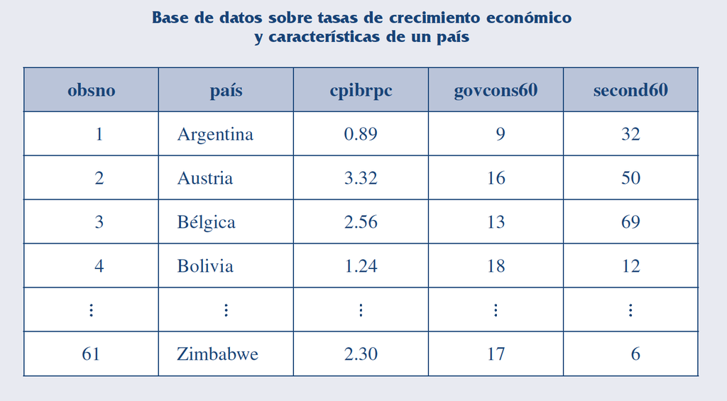

- Datos de combinación de cortes transversales: Combinación de dos o más muestras de datos de corte transversal.

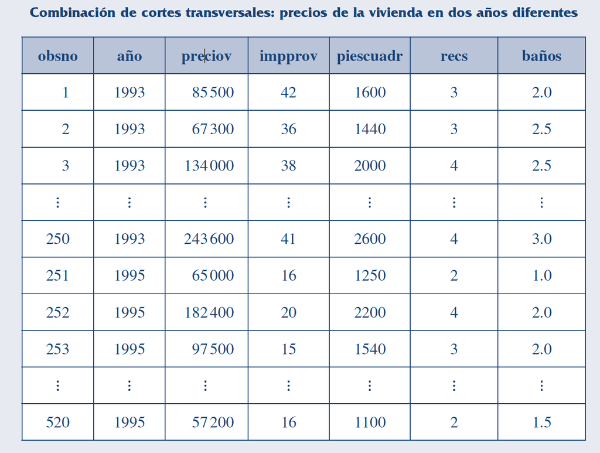

- **Datos de series de tiempo**: Observaciones de una o varias variables a lo largo del tiempo.

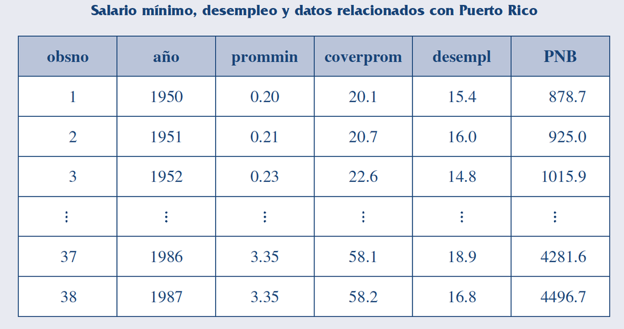

- Datos panel: Serie de tiempo por cada unidad de una base de datos de corte transversal.

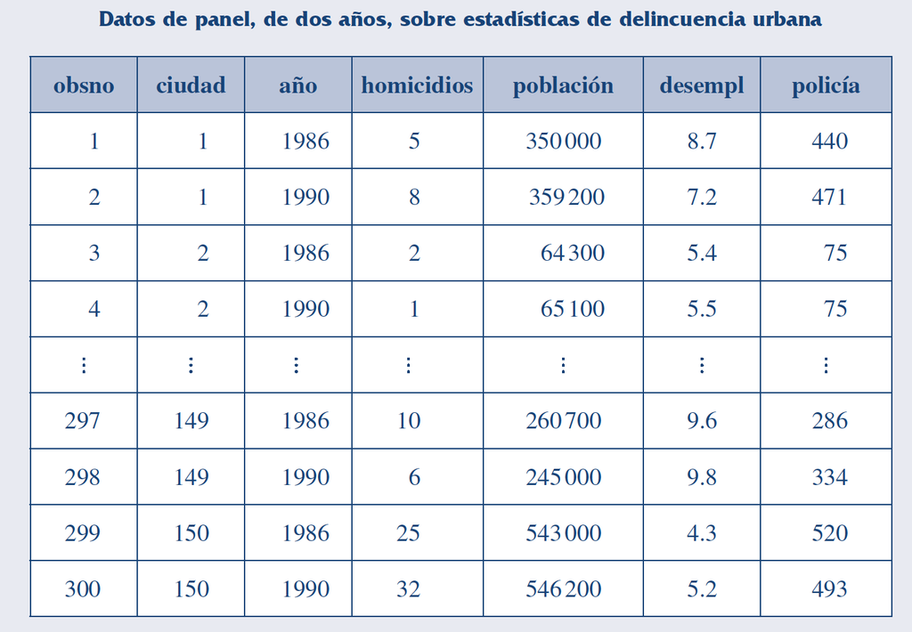

Características de las series de tiempo:

**Revisar:** Wooldridge - Cap. 10.1 & 1.3.

- Orden temporal: El pasado afecta al futuro.

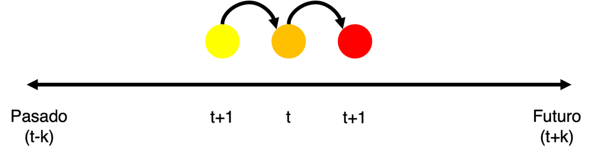

- Aleatoriedad en las series de tiempo: Los datos como resultados de variables aleatorias.

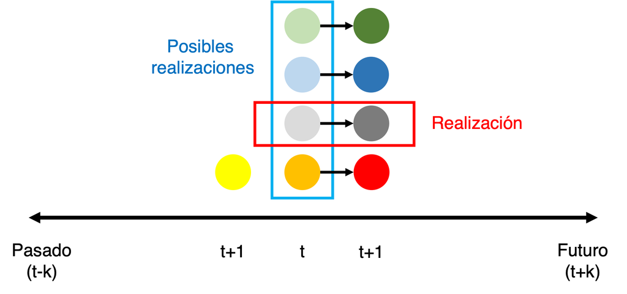

- Periodicidad de los datos: La frecuencia de recolección de la información.

## 1.3. Componentes de las series de tiempo

Los componentes latentes de una serie de tiempo son:

**Revisar:** Bee Dagum & Bianconcini - Cap. 2.1.

1. Tendencia ($T$): El valor esperado de largo plazo (tendencia secular).
2. Ciclo ($C$): Movimientos sobrepuestos a lo largo de la tendencia de largo plazo.
3. Estacional ($S$): Movimientos de corto plazo (menos de un año) sistemáticos a lo largo de la serie de tiempo.
4. Irregular ($I$): Componente aleatorio de la serie.

Los componentes pueden ser aditivos o multiplicativos:

- Aditivo: $y_t = T_t + C_t + S_t + I_t$
- Multiplicativo: $y_t = T_t \times C_t \times S_t \times I_t$

Ejemplo con el IMAE de Nicaragua:

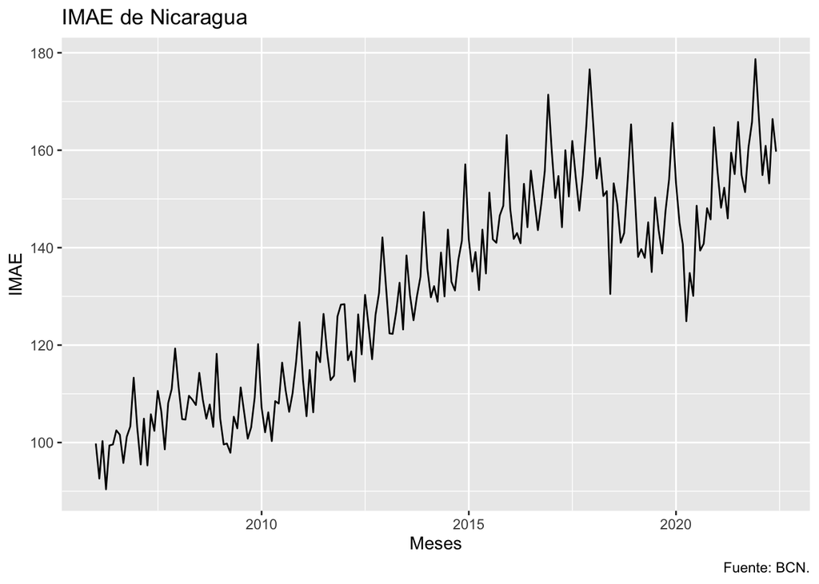

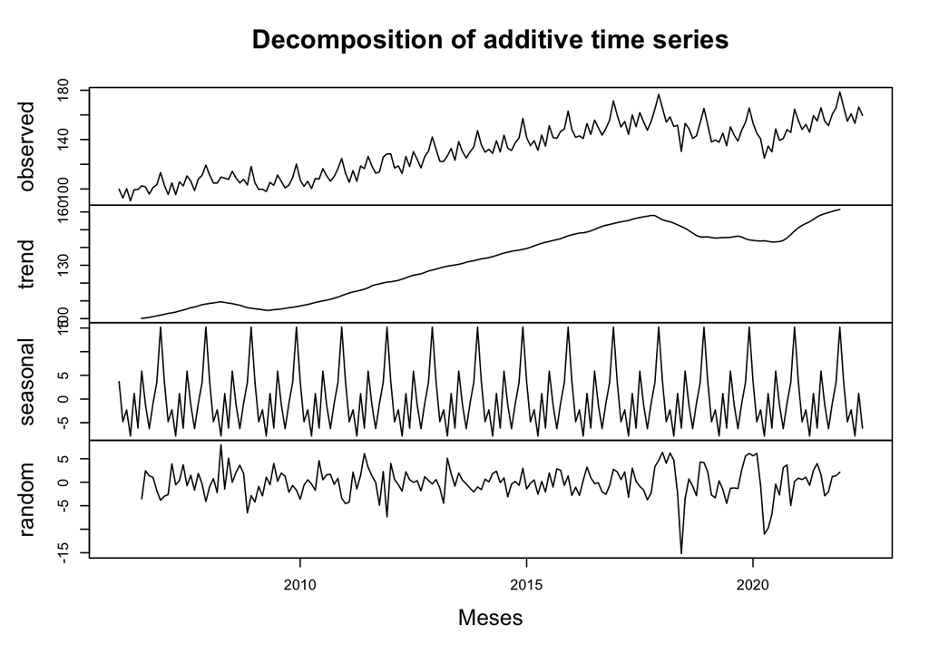

## 1.4. Modelos de regresión de series de tiempo

Algunos modelos de series de tiempo:

- Modelos estáticos. Modeliza la relación contemporánea entre las variables.

$y_t = \beta_0 + \beta_1 z_t + u_t, \:t = 1, 2, \,..., n$

- Modelos con rezagos distribuidos finitos (FDL). Modeliza la relación de cuando una o más variables influyen en $y$ en forma rezagada.

Generalizando:$y_t = \alpha_0 + \delta_0 z_t + \delta_1 z_{t-1} + \delta_2 z_{t-2} + \, ... \, + \delta_q z_{t-q} + u_t$

$y_t = \alpha_0 + \delta_0 z_t + \delta_1 z_{t-1} + \delta_2 z_{t-2} + u_t, \:t = 1, 2, \,..., n$

Propensión de impacto ($\delta_0$): Cambio inmediato en $y$ debido al aumento de 1 unidad de $z$.

Distribución de rezagos ($\delta_j$):

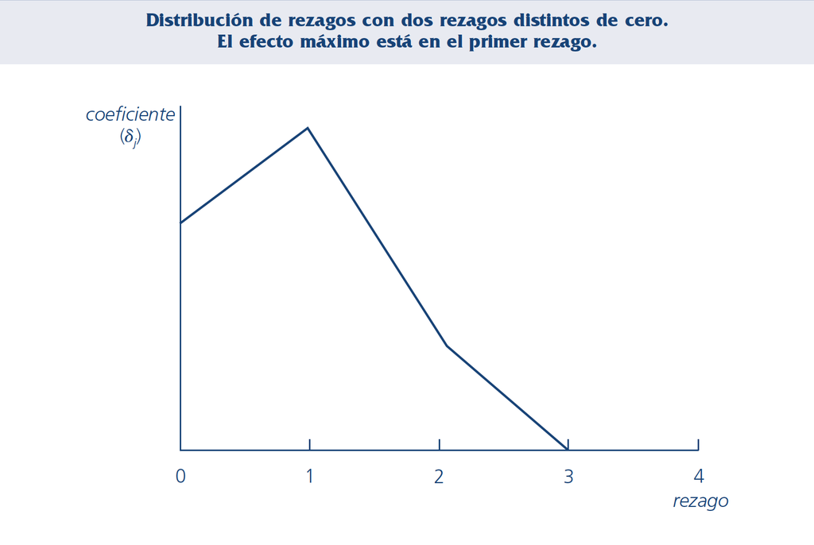

Propensión de largo plazo (LRP): El cambio en $y$ debido a un cambio permanente de $z$. Es la suma de los coeficientes de la $z$ actual y sus rezagos ($\delta_0 + \delta_1 + \delta_2$).

# S2: Propiedades de muestras finitas de MCO bajo los supuestos clásicos

## 2.1. Datos de la sesión

**Fecha de la sesión:** 2022-08-31

**Lecturas obligatorias:**

- Wooldridge - Cap. 10.3

**Lecturas opcionales:**

- Wooldridge - Cap. 2-4

## 2.2. Insesgamiento de MCO

**Revisar:** Supuestos de la Regresión Lineal Múltiple (RLM) en Wooldridge - Cap. 3.3.

**Supuesto ST.1: Lineal en los parámetros**

El proceso estocástico $\{ (x_{t1},\, x_{t2},\, ...,\, x_{tk}, \, y_{t}): \: t = 1, \, 2, \, ..., \, n \}$ sigue el modelo lineal:

$y_t = \beta_0 + \beta_1 x_{t1} + \beta_2 x_{t2} + \, ... \, + \beta_k x_{tk} + u_t,$

donde $\{u_t: \, t = 1, \, 2, \, ..., \, n\}$ es la secuencia de errores, y $n$ es el número de observaciones.

**Supuesto ST.2: No hay colinealidad perfecta**

En la muestra no hay variables independientes que sean constantes ni que sean una combinación lineal perfecta de las otras.

**Supuesto ST.3: Media condicional cero**

Para cada $t$, dadas las variables explicativas para todos los periodos, el valor esperado del error $u$, es cero. Matemáticamente:

$\mathsf{E}(u_t | \textbf{X}) = 0, \, t = 1, \, 2, \, ..., \, n.$

**Teorema ST.1: Insesgamiento de los estimadores de MCO**

Bajo los supuestos ST.1, ST.2, y ST.3, los estimadores de MCO son insesgados condicionales sobre $\textbf{X}$, y por tanto también incondicionalmente: $\mathsf{E}(\widehat{\beta}_j) = \beta_j, \, j = 0, \, 1, \, ..., \, k.$

## 2.3. Teorema Gauss-Markov

**Revisar:** Supuestos de Gauss-Markov en Wooldridge - Cap. 3.4-3.5.

**Supuesto ST.4: Homocedasticidad**

La varianza de $u_t$, condicional en $\textbf{X}$, es la misma para cualquier $t: \, \mathsf{Var}(u_t | \textbf{X}) = \mathsf{Var}(u_t) = \sigma^2, \, t=1, \, 2, \, ..., \, n.$

**Supuesto ST.5: No hay correlación serial**

Los errores, condicionales sobre $\textbf{X}$, en dos periodos distintos, no están correlacionados: $\mathsf{Corr}(u_t, u_s | \textbf{X}) = 0$, para cualquier $t \neq s$.

**Teorema ST.2: Varianzas de muestreo de los estimadores de MCO**

$\mathsf{Var}(\widehat{\beta}_j | \textbf{X}) = \frac{ \sigma^2}{STC_j (1-R^2_j)}, \, j = 1, \, ...,\, k,$

donde $STC_j$ es la suma total de cuadrados de $x_{tj}$ y $R^2_j$ es la R-cuadrada de la regresión de $x_j$ sobre las otras variables independientes.

**Teorema ST.3: Estimación insesgada de $\sigma^2$**

Bajo los supuestos ST.1 a ST.5, el estimador $\widehat{\sigma^2} = \frac{SRC}{gl}$ es un estimador insesgado $\sigma^2$, donde $gl = n-k-1$.

**Teorema ST.4: Teorema Gauss-Markov**

Bajo los supuestos ST.1 a ST.5, los estimadores de MCO son los mejores estimadores lineales insesgados condicionales sobre $\textbf{X}$.

## 2.4. Inferencia

**Revisar:** Supuestos de distribución de muestreo en Wooldridge - Cap. 4.1.

**Supuesto ST.6: Normalidad**

Los errores $u_t$ son independientes de $\textbf{X}$ y son independientes e idénticamente distribuidos como $\mathsf{Normal}(0, \, \sigma^2)$.

**Teorema ST.5: Distribuciones de muestreo normales**

Bajo los supuestos ST.1 a ST.6, los supuestos del MCL para series de tiempo, los estimadores de MCO se distribuyen de forma normal, condicionales sobre $\textbf{X}$.

Bajo la hipótesis nula, cada estadístico $t$ tiene una distribución $t$, y cada estadístico $F$ tiene una distribución $F$. También es válida la construcción usual de los intervalos de confianza.

# S3: Introducción a R

## 3.1. Datos de la sesión

**Fecha de la sesión:** 2022-09-05

## 3.2. Script

**Tomado de:** Healy, K. (2008). Data Visualization. A practical introduction (https://socviz.co).

Les comparto el script de la clase de hoy.

```r
# Instalacion de paquetes
my_packages <- c("tidyverse", "broom", "coefplot", "cowplot",
                 "gapminder", "GGally", "ggrepel", "ggridges", "gridExtra",
                 "here", "interplot", "margins", "maps", "mapproj",
                 "mapdata", "MASS", "quantreg", "rlang", "scales",
                 "survey", "srvyr", "viridis", "viridisLite", "devtools")

install.packages(my_packages, repos = "http://cran.rstudio.com")

## Uso de librerias
library(devtools)
install_github("kjhealy/socviz")
devtools::install_github("kjhealy/socviz")

# Introduccion
## Librerias
library(tidyverse)
library(socviz)
library(gapminder)

## Objetos
c (1, 2, 3, 1, 3, 5, 25)
my_numbers <- c (1, 2, 3, 1, 3, 5, 25)
your_numbers <- c(5, 31, 29, 4, 89, 43)

my_numbers
your_numbers

## Funciones
### Help
? mean

mean(my_numbers)
mean_my_numbers <- mean(my_numbers)

# Dataframes
titanic
class(titanic)
class(my_numbers)
class(my_packages)
titanic$percent

## Crear un data frame
url <- "https://cdn.rawgit.com/kjhealy/viz-organdata/master/organdonation.csv"
organs <- read_csv(file = url)

# Plots
gapminder
p <- ggplot(data = gapminder,
       mapping  = aes(x = gdpPercap, y = lifeExp))
p + geom_point()
```

# S4: Gráficos y series de tiempo en R

## 4.1. Datos de la sesión

**Fecha de la sesión:** 2022-09-12

## 4.2. Script

```r
install.packages("fpp")
install.packages("Ecdat")
install.packages("forecast")


# Librerias ----
library(fpp)
library(forecast)

# Descomposicion de TS aditiva ----
data(ausbeer)
tibble::tibble(data(ausbeer))
ts_beer = tail(head(ausbeer, 17*4+2), 17*4-4)
ts_beer <- as.ts(ts_beer)
plot(ts_beer)

## Tendencia-ciclo ----

trend_beer <- ma(ts_beer, order = 4, centre = T)
trend_beer <- as.ts(trend_beer)
plot(ts_beer)
lines(trend_beer)

## Estacional-irregular ----
detrend_beer <- as.ts(ts_beer - trend_beer)
plot(detrend_beer)

## Estacionalidad promedio ----
seas_beer <-  t(matrix(data = detrend_beer, nrow = 4))
seas_beer <- as.ts(rep(colMeans(seas_beer, na.rm = T), 16))
plot(seas_beer)

## Commando decompose
ts_beer <- ts(ts_beer, frequency = 4)
decompose_beer <- decompose(ts_beer, "additive")
plot(as.ts(decompose_beer$trend))
plot(as.ts(decompose_beer$seasonal))
plot(as.ts(decompose_beer$random))
plot(decompose_beer)

# Descomposicion de TS multiplicativa ----
decompose_beer <- decompose(ts_beer, "multiplicative")
plot(as.ts(decompose_beer$trend))
plot(as.ts(decompose_beer$seasonal))
plot(as.ts(decompose_beer$random))
plot(decompose_beer)
```

# S5: Tendencia y estacionalidad

## 5.1. Datos de la sesión

**Fecha de la sesión:** 2022-09-25

**Lecturas obligatorias:**

- Wooldridge - Cap. 10.5

## 5.2. Caracterización

**Tendencia lineal:** Si se mantienen fijos todos los demás factores, $\alpha_1$ mide el cambio en $y_t$ de un periodo al siguiente debido al transcurso del tiempo:

$y_t = \alpha_0 + \alpha_1 t + e_t, \: t = 1, 2, \, ..., k$

Si consideramos que $e_t$, es una secuencia independiente e idénticamente distribuida (i.i.d.), entonces:

$\Delta y_t = y_t - y_{t-1} = \alpha_1$

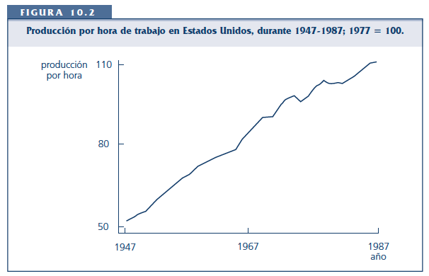

**Tendencia exponencial:**

Es cuando una serie de tiempo tiene la misma tasa de crecimiento de una período a otro.

$log(y_t) = \beta_0 + \beta_1 t + e_t, \: t = 1, 2, \, ..., k$

$\Delta log(y_t) = \beta_1$

$\Delta log(y_t) \approx \frac{y_t - y_{t-1}}{y_{t-1}}$

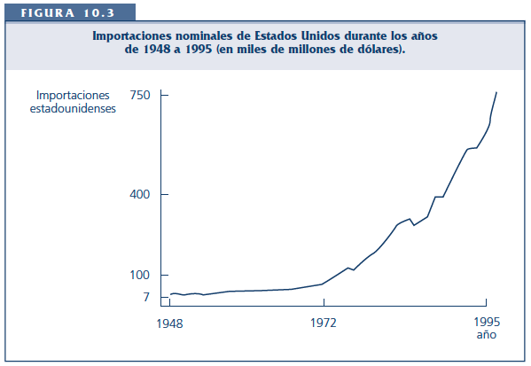

## 5.3. Regresión espuria

- Pueden existir factores inobservables con tendencia que afectan a $y_t$ que pueden estar correlaciones con las variables explicativas.
- Esto puede derivar en establecer una relación falsa entre $y_t$ y una o más variables explicativas.
- Se debe de incluir la tendencia en el tiempo en el modelo:

$y_t = \beta_0 + \beta_1 x_{t1} + \beta_2 x_{t2} + \beta_3 t + u_t$

- Se debe de incluir una tendencia en la regresión si alguna variable independiente tiene tendencia, incluso si $y_t$ no la tiene.

## 5.4. Regresión en R

```r
library(fpp)
library(tidyverse)
library(readxl)
library(forecast)

# Wooldridge - Ej. 10.7 (pág. 363)

data_hseinv <- read_csv(url("https://raw.githubusercontent.com/alvarole/econometria2/main/02_data/wooldridge-hseinv.csv"))

data_model <- data_hseinv %>%
  select(year, t, linvpc, lprice)

p <- ggplot(data_model, mapping = aes(x = year, y = linvpc))
p + geom_line()

p <- ggplot(data_model, mapping = aes(x = year, y = lprice))
p + geom_line()

lmodel <- lm(linvpc ~ lprice + year, data = data_model)
summary(lmodel)

lmodel <- lm(linvpc ~ lprice + t, data = data_model)
summary(lmodel)
```

# S6: Laboratorio No. 1

## 6.1. Datos de la sesión

**Fecha de la sesión:** 2022-09-26

## 6.2. Creación de base de datos

```r
# Librerias

library(tidyverse)
library(readxl)
library(forecast)

# Data cleaning
data_lab1 <- read_csv(url("https://raw.githubusercontent.com/alvarole/econometria2/main/03_assignments/lab1_data.csv")) %>%
  rename(pib = PIB,
         consumo = "Consumo...4",
         gasto = Gasto,
         inversion = Inversion,
         export = Exportaciones,
         import = Importaciones) %>%
  select(-"Consumo...3")
```

# S8: Examen No. 1

## 8.1. Datos de la sesión

**Fecha de la sesión:** 2022-10-03

# S7: Estacionariedad y dependencia (1)

## 7.1. Datos de la sesión

**Fecha de la sesión:** 2022-09-29

**Lecturas obligatorias:**

- Wooldridge - Cap. 11.1

## 7.2. Estacionariedad

- Simplifica los enunciados de la ley de los grandes números y el teorema del límite central para los procesos estocásticos.
- Un **proceso estocástico estacionario** es aquel en el que sus distribuciones de probabilidad se mantienen estables con el paso del tiempo.
- **Formalmente:** El proceso estocástico ${x_t: \, t = 1, 2, …}$ es estacionario si para cada conjunto de índices temporales $1 \leq t_1 < t_2 < … < t_m$, la distribución conjunta de $(x_{t_1}, x_{t_2}, …, x_{t_m})$ es la misma que la distribución conjunta de $(x_{t_1+h}, x_{t_2+h}, …, x_{t_m+h})$ para todos los enteros $h \geq 1$.
- Es decir, si se toma cualquier colección de variables aleatorias de la secuencia y se las desplaza $h$ periodos, la **distribución de probabilidad conjunta permanece inalterada**.
- **Proceso estacionario en covarianza:** Un proceso estocástico ${x_t: \, t = 1, 2, …}$ con un segundo momento finito $[E(x_t^2)< \infty]$ es estacionario en covarianza si i) $E(x_t)$ es constante; ii) $Var(x_t)$ es constante; y iii) para cualquier $t$, $h \leq 1$, la $Cov(x_t, x_{t+h})$ depende sólo de $h$ no de $t$.

## 7.3. Dependencia

- **Dependencia**: Se dice que un proceso de serie de tiempo estacionario ${x_t: \, t = 1, 2, …}$ es débilmente dependiente si $x_t$ y $x_{t+h}$ son “casi independientes” a medida que $h$ aumenta sin límite.
- Una serie de tiempo estacionaria en covarianza es débilmente dependiente si la correlación entre $x_t$ y $x_{t+h}$ se vuelve cero con la “suficiente rapidez” cuando $h → \infty$.
- Las secuencias estacionarias en covarianza donde la $Corr(x_t, x_{t+h}) → 0$ cuando $h → \infty$. se dice que están no correlacionadas asintóticamente.
- Los procesos MA y AR son secuencias débilmente dependiente.

# S9: Estacionariedad y dependencia (2)

## 9.1. Datos de la sesión

**Fecha de la sesión:** 2022-10-05

**Lecturas obligatorias:**

- Wooldridge - Cap. 11.1 & 11.3

## 9.2. Procesos MA y AR

- La evolución de un proceso estocástico con base a una sucesión de choques aleatorios es un proceso de **media móvil (MA(q))**.
- Un proceso MA de orden uno (MA(1)) tiene la forma:

$x_t = e_t + \alpha_1 e_{t-1}, \, t = 1, 2, ...., k$

- Es decir, $x_t$ es un promedio ponderado de $e_t$ y $e_{t-1}$, y $e_t$ es una secuencia i.i.d. con media cero y varianza $\sigma_e^2$.
- La evolución de un proceso estocástico con base del valor de la serie de uno o más períodos anteriores y un término estocástico es un proceso **autorregresivo (AR(p))**.
- Un proceso AR de orden uno (AR(1)) tiene la forma:

$y_t = p_1 y_{t-1} + e_{t}, \, t = 1, 2, ...., k$

- El punto de partida es la secuencia es $y_0$ (en $t = 0$), y $e_t$ es una secuencia i.i.d. con media cero y varianza $\sigma_e^2$. También se supone que las $e_t$ son independientes de $y_0$ así como que $E(y_0) = 0$, y que $|p_1|<1$ para que las series sean débilmente dependientes.

## 9.3. Procesos estocásticos altamente persistentes

- Proceso de raíz unitaria viene del hecho de que $p_1 = 1$.
- La varianza de un proceso de raíz unitaria aumenta como una función del tiempo.
- Cuando en una ecuación de regresión se usan procesos estocásticos altamente persistentes se pueden violar los supuestos del MCL.
- Comúnmente los procesos de raíz unitaria son integrados de orden uno, o I(1). Esto significa que la primera diferencia del proceso es débilmente dependiente (y a menudo estacionaria).
- Una serie de tiempo I(1) a menudo se considera un proceso estacionario en diferencias, aun cuando en cierto modo el nombre es engañoso respecto al énfasis que se pone en la estacionariedad después de la diferenciación, en vez de la **dependencia débil en las diferencias**.

$\Delta y_t = y_t - y_{t-1} = e_t, \, t = 2, 3, ...., k$

Cuando las series en cuestión tienen una tendencia marcada hacia arriba o hacia abajo, es mejor obtener la autocorrelación de primer orden después de eliminar tal tendencia.

# S10: Pruebas de raíz unitaria

## 10.1. Datos de la sesión

**Fecha de la sesión:** 2022-10-19

## 10.2. Script

```r
# Librerias ----
library(dplyr)
library(tidyverse)
library(tseries)
library(urca)
library(lubridate)


# Serie de ruido blanco
white_noise <- rnorm(10000)
ts.plot(white_noise)


# Dickey-Fuller aumentada
wn_adf <- ur.df(white_noise, type ="none", selectlags = "BIC")
summary(wn_adf)

# Phillip-Perron
wn_pp <- ur.pp(white_noise, type = "Z-tau", model = "constant", lags = "short")
summary(wn_pp)

# KPSS
wn_kpss <- ur.kpss(white_noise, type = "tau", use.lag = 1)
summary(wn_kpss)

# Data
data(nporg)
gnp <- nporg %>% select(gnp.r) %>% drop_na(gnp.r)
gnp <- ts(gnp)
ts.plot(gnp)

d_gnp <- diff(gnp)
ts.plot(d_gnp)
ts.plot(white_noise)
```

# S11: Autocorrelación

## 11.1. Datos de la sesión

**Fecha de la sesión:** 2022-10-19

**Lecturas obligatorias:**

- Wooldridge - Cap. 12.1

## Propiedadades de los MCO con errores correlacionados serialmente

**Teorema ST.1: Insesgamiento de los estimadores de MCO**

Bajo los supuestos ST.1, ST.2, y ST.3, los estimadores de MCO son insesgados condicionales sobre $\textbf{X}$, y por tanto también incondicionalmente: $\mathsf{E}(\widehat{\beta}_j) = \beta_j, \, j = 0, \, 1, \, ..., \, k.$

**Teorema ST.4: Teorema Gauss-Markov**

Bajo los supuestos ST.1 a ST.5, los estimadores de MCO son los mejores estimadores lineales insesgados condicionales sobre $\textbf{X}$.

- Los estimadores MCO ya no son BLUE en presencia de correlación serial.
- Los errores estándar usuales de MCO y los estadísticos de prueba pierden validez.
- El estimador usual de la varianza es sesgado para $Var(\widehat{\beta}_1)$ en presencia de correlación serial.

# S12: Autocorrelación en R

## 12.1. Datos de la sesión

**Fecha de la sesión:** 2022-10-19

## 12.2. Script

```r
# Librerias ----
library(dplyr)
library(tidyverse)
library(tseries)
library(purrr)
library(urca)
# devtools::install_github("KevinKotze/tsm")
library(tsm)
library(forecast)


# Serie AR
set.seed(123)

x <- arima.sim(model = list(ar = 0.8), n = 1000)
plot.ts(x)

ac(x, max.lag = 30)

Box.test(x, lag = 1, type = "Ljung-Box")

q.stat <- rep(0, 10)
q.prob <- rep(0, 10)

for (i in 1:10) {
  q.stat[i] <- Box.test(x, lag = i, type = "Ljung-Box")$statistic
  q.prob[i] <- Box.test(x, lag = i, type = "Ljung-Box")$p.value

}

par(mfrow = c(1, 2))
plot(q.stat)
plot(q.prob)

arima100 <- arima(x, order = c(1, 0, 0), include.mean  = FALSE)
arima100

par(mfrow = c(1, 1))
plot(arima100$residuals)

ac(arima100$residuals, max.lag = 30)

for (i in 1:10) {
  q.stat[i] <- Box.test(arima100$residuals, lag = i, type = "Ljung-Box")$statistic
  q.prob[i] <- Box.test(arima100$residuals, lag = i, type = "Ljung-Box")$p.value
}

plot(q.stat)
plot(q.prob)

# Serie MA
y <- arima.sim(model = list(ma = 0.8), n = 1000)
plot(y)

ac(y, max.lag = 30)

arima001 <- arima(y, order = c(0, 0, 1), include.mean  = FALSE)
ac(arima001$residuals, max.lag = 30)

# Serie ARMA
z <- arima.sim(model = list(ar = c(0.6, -0.2), ma = c(0.4)), n = 1000)
ac(z, max.lag = 30)

arima302 <- arima(z, order = c(3, 0, 2), include.mean  = FALSE)
ac(arima302$residuals, max.lag = 30)

arima201 <- arima(z, order = c(2, 0, 1), include.mean  = FALSE)
ac(arima201$residuals, max.lag = 30)

arima302$aic
arima201$aic
```